# BUGS Example Vol II: Stagnant

# Stagnant Data

In this data, X represents the logarithm of the flow rate of water down an inclined channel (grams per centimetre per second) and Y represents the logarithm of the height of the stagnant surface layer (centimetres) for different surfactants.

```r
N = 29

Y = c(1.12, 1.12, 0.99, 1.03, 0.92, 0.90, 0.81, 0.83, 0.65, 0.67, 0.60,
      0.59, 0.51, 0.44, 0.43, 0.43, 0.33, 0.30, 0.25, 0.24, 0.13, -0.01,
      -0.13,  -0.14, -0.30, -0.33, -0.46,  -0.43, -0.65)

x = c(-1.39, -1.39, -1.08, -1.08, -0.94, -0.80, -0.63, -0.63, -0.25,
      -0.25, -0.12, -0.12, 0.01, 0.11, 0.11, 0.11,  0.25, 0.25, 0.34,
      0.34, 0.44, 0.59, 0.70, 0.70, 0.85, 0.85,  0.99, 0.99, 1.19)

inits1 = list(chain1 = list(alpha = 0.2, beta = c(-0.45, -1.0), tau = 5, k = 16),
              chain2 = list(alpha = 0.6, beta = c(-0.45, -1.0), tau = 5, k = 8))

inits2 = list(chain1 = list(alpha = 0.47, beta = c(-0.45, -1.0), tau = 5, x.change = 0.5),
              chain2 = list(alpha = 0.47, beta = c(-0.45, -1.0), tau = 5, x.change = 0.5))
```

Now we are visualizing the data and also taking a look at the solution found in the BUGS example.

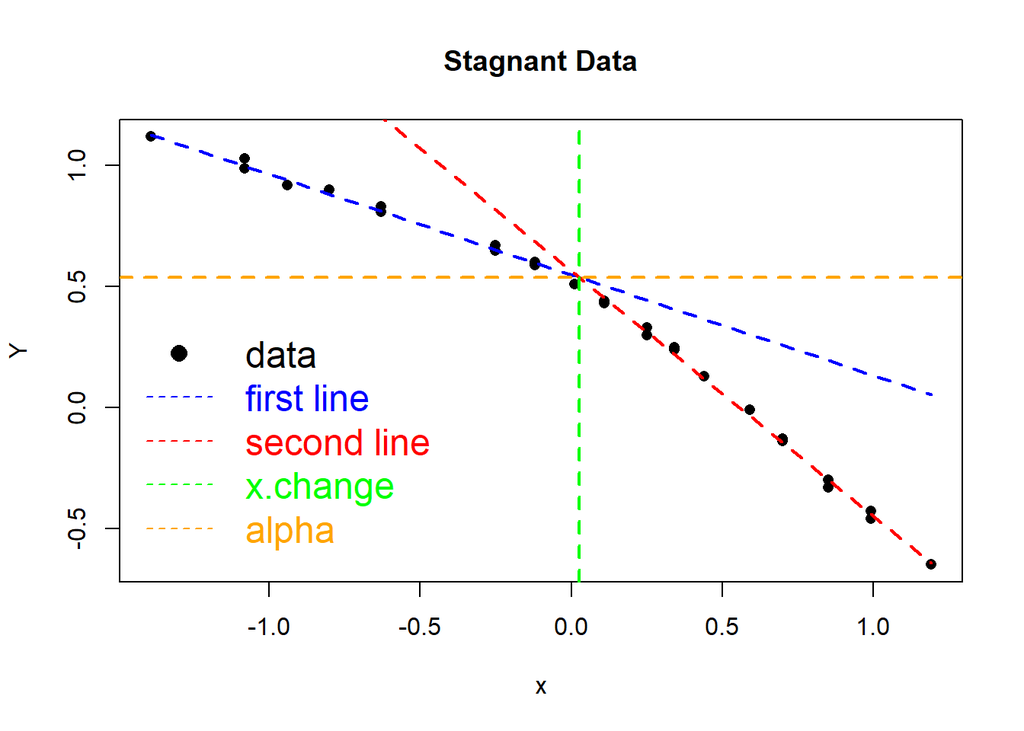

```r
alpha.mean = 0.538
beta1.mean = -0.417
beta2.mean = -1.015
sigma.mean = 0.02214
x.change.mean = 0.02557

line1 = alpha.mean + beta1.mean * (x - x.change.mean)
line2 = alpha.mean + beta2.mean * (x - x.change.mean)

plot(x, Y, main="Stagnant Data", xlab="x", ylab="Y", pch = 16)
lines(x, line1, col="blue", lwd=2, lty=2)
lines(x, line2, col="red", lwd=2, lty=2)
# points(c(x.change.mean), (alpha.mean), pch=23, cex=1.5, col="black", bg="purple")
abline(v=x.change.mean, col = "green", lwd=2, lty=2)
abline(h=alpha.mean, col = "orange", lwd=2, lty=2)
legend("bottomleft",
       inset = 0.02,
       cex = 1.5,
       bty = "n",
       legend = c("data", "first line", "second line", "x.change", "alpha"),
       col = c("black", "blue", "red", "green", "orange"),
       text.col = c("black", "blue", "red", "green", "orange"),
       lty = c(NA, 2, 2, 2, 2),
       pch = c(16, NA, NA, NA, NA))
```

We use this function to plot the traces.

```r
plot.results = function(chain1, chain2, monitors, main) {
   par(mfrow = c(length(monitors), 1), mar = c(4.1, 4.1, 0.5, 0.5),
       mgp = c(2.3, 1, 0), oma = c(0, 0, 3, 0))

   for(i in 1:length(monitors)) {
      plot(chain1[[monitors[i]]], type = "l", col = "red", xlab = "iteration",
           ylab = monitors[i], ylim = range(c(chain1[[monitors[i]]], chain2[[monitors[i]]])))
      lines(chain2[[monitors[i]]], col = "blue")
   }

   title(main = main, outer = T, line = 1)

   par(mfrow = c(1, 1), mar = c(5.1, 4.1, 4.1, 2.1), mgp = c(3, 1, 0),
       oma = c(0, 0, 0, 0))
}
```

# First model

Let’s implement the first model from the BUGS example in the different frameworks. The BUGS code for the code looks like this:

```r
cat("model {
  for(i in 1:N) {
    Y[i] ~ dnorm(mu[i],tau)
    mu[i] <- alpha + beta[J[i]] * (x[i] - x[k])
    J[i] <- 1 + step(i - k - 0.5)
    punif[i] <- 1/N
  }
  tau ~ dgamma(0.001,0.001)
  alpha ~ dnorm(0.0,1.0E-6)
  for(j in 1:2) {
    beta[j] ~ dnorm(0.0,1.0E-6)
  }
  k ~ dcat(punif[])
  sigma <- 1 / sqrt(tau)
}")
```

```
## model {
##   for(i in 1:N) {
##     Y[i] ~ dnorm(mu[i],tau)
##     mu[i] <- alpha + beta[J[i]] * (x[i] - x[k])
##     J[i] <- 1 + step(i - k - 0.5)
##     punif[i] <- 1/N
##   }
##   tau ~ dgamma(0.001,0.001)
##   alpha ~ dnorm(0.0,1.0E-6)
##   for(j in 1:2) {
##     beta[j] ~ dnorm(0.0,1.0E-6)
##   }
##   k ~ dcat(punif[])
##   sigma <- 1 / sqrt(tau)
## }
```

## OpenBUGS

Now we use R2OpenBUGS to sample from the posterior.

```r
library(R2OpenBUGS)
data = list("N", "Y", "x")

par1 = c("alpha", "k")

openbugs.results1 = bugs(data = data,
                         inits = inits1,
                         parameters.to.save = par1,
                         model = "stagnant_model1.txt",
                         n.chains = 2,
                         n.iter = 10000,
                         n.thin = 1,
                         n.burnin = 0,
                         debug = FALSE,
                         DIC = TRUE)

# Print summary
print(openbugs.results1)
```

```
## Inference for Bugs model at "stagnant_model1.txt",
## Current: 2 chains, each with 10000 iterations (first 0 discarded)
## Cumulative: n.sims = 20000 iterations saved
##            mean   sd   2.5%    25%   50%   75% 97.5% Rhat n.eff
## alpha       0.8  0.2    0.5    0.5   0.7   1.0   1.0 27.0     2
## k          10.3  2.8    7.0    8.0  10.2  13.0  13.0 14.4     2
## deviance -104.6 39.4 -148.2 -144.6 -69.7 -66.2 -59.4 28.2     2
##
## For each parameter, n.eff is a crude measure of effective sample size,
## and Rhat is the potential scale reduction factor (at convergence, Rhat=1).
##
## DIC info (using the rule, pD = var(deviance)/2)
## pD = 5.8 and DIC = -98.8
## DIC is an estimate of expected predictive error (lower deviance is better).
```

Now we take a look at the trace for the first model. As we can see it doesn’t converge, which is due the correlation between alpha (the intercept) and k (the index for the changepoint in the data).

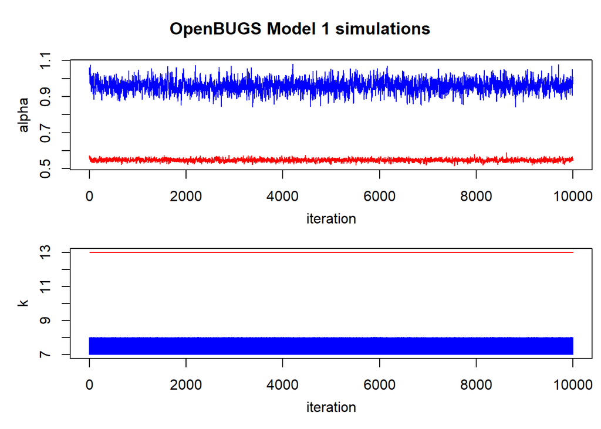

```r
sims = openbugs.results1$sims.array

plot.results(list("alpha" = sims[,1,"alpha"],
                  "k" = sims[,1,"k"]),
             list("alpha" = sims[,2,"alpha"],
                  "k" = sims[,2,"k"]),
             monitors = c("alpha", "k"),
             main = "OpenBUGS Model 1 simulations")
```

## JAGS

Now we use JAGS to sample from the posterior.

```r
library(R2jags)
data = list("N", "Y", "x")

par1 = c("alpha", "k")

jags.result1 = jags(data = data,
                    inits = inits1,
                    parameters.to.save = par1,
                    model = "stagnant_model1.txt",
                    n.chains = 2,
                    n.iter = 10000,
                    n.thin = 1,
                    n.burnin = 0,
                    DIC = TRUE)
```

```
## module glm loaded
```

```r
# Print summary
print(jags.result1)
```

```
## Inference for Bugs model at "stagnant_model1.txt", fit using jags,
##  2 chains, each with 10000 iterations (first 0 discarded)
##  n.sims = 20000 iterations saved
##           mu.vect sd.vect     2.5%      25%      50%     75%   97.5%   Rhat
## alpha       0.396   0.253    0.069    0.120    0.494   0.640   0.658  8.994
## k          16.441   5.067   11.000   12.000   14.500  22.000  22.000 12.188
## deviance -100.466  24.148 -125.839 -122.793 -115.764 -73.948 -65.624  5.004
##          n.eff
## alpha        2
## k            2
## deviance     2
##
## For each parameter, n.eff is a crude measure of effective sample size,
## and Rhat is the potential scale reduction factor (at convergence, Rhat=1).
##
## DIC info (using the rule, pD = var(deviance)/2)
## pD = 58.2 and DIC = -42.3
## DIC is an estimate of expected predictive error (lower deviance is better).
```

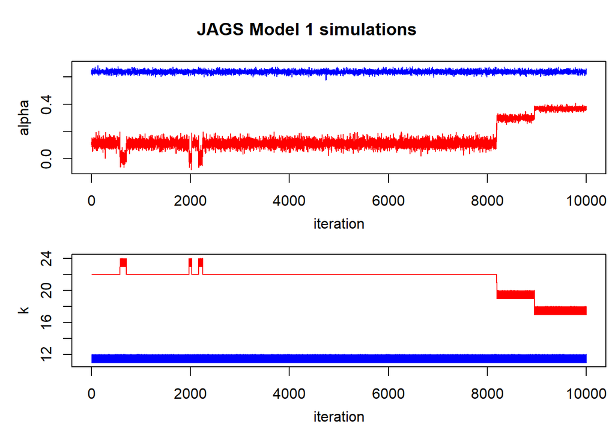

```r
sims = jags.result1$BUGSoutput$sims.array

plot.results(list("alpha" = sims[,1,"alpha"],
                  "k" = sims[,1,"k"]),
             list("alpha" = sims[,2,"alpha"],
                  "k" = sims[,2,"k"]),
             monitors = c("alpha", "k"),
             main = "JAGS Model 1 simulations")
```

## Nimble

```r
library(nimble, warn.conflicts = FALSE)
dataNimble = list(x = x, Y = Y)
constants = list(N = N)
monitors.model1 = list("alpha", "k")

# model configuration
code.model1 = nimbleCode({
   for(i in 1 : N) {
      Y[i] ~ dnorm(mu[i],tau)
      mu[i] <- alpha + beta[J[i]] * (x[i] - x[k])
      J[i] <- 1 + step(i - k - 0.5)
      punif[i] <- 1/N
   }
   tau ~ dgamma(0.001,0.001)
   alpha ~ dnorm(0.0,1.0E-6)
   for( j in 1 : 2 ) {
      beta[j] ~ dnorm(0.0,1.0E-6)
   }
   k ~ dcat(punif[1:N])
   sigma <- 1 / sqrt(tau)
})

nimble.model1 = nimbleModel(code.model1,
                            constants = constants,
                            data = dataNimble,
                            inits = inits1$chain1)
```

```
## defining model...
```

```
## building model...
```

```
## setting data and initial values...
```

```
## running calculate on model (any error reports that follow may simply reflect missing values in model variables) ...
## checking model sizes and dimensions...
## model building finished.
```

```r
# MCMC configuration and building
mcmc.conf.model1 = configureMCMC(nimble.model1, monitors = monitors.model1)
```

```
## ===== Monitors =====
## thin = 1: alpha, k
## ===== Samplers =====
## conjugate sampler (4)
##   - tau
##   - alpha
##   - beta[]  (2 elements)
## categorical sampler (1)
##   - k
```

```r
mcmc.model1 = buildMCMC(mcmc.conf.model1, monitors = monitors.model1)

# compile to C++, and run
compiled.model1 = compileNimble(nimble.model1)
```

```
## compiling... this may take a minute. Use 'showCompilerOutput = TRUE' to see C++ compilation details.
## compilation finished.
```

```r
compiled.mcmc.model1 = compileNimble(mcmc.model1, project = nimble.model1)
```

```
## compiling... this may take a minute. Use 'showCompilerOutput = TRUE' to see C++ compilation details.
## compilation finished.
```

```r
# run multiple MCMC chains
nimble.results1 = runMCMC(compiled.mcmc.model1,
                          nburnin = 0,
                          inits = inits1,
                          niter = 10000,
                          nchains = 2,
                          summary = TRUE)
```

```
## running chain 1...
```

```
## |-------------|-------------|-------------|-------------|
## |-------------------------------------------------------|
```

```
## running chain 2...
```

```
## |-------------|-------------|-------------|-------------|
## |-------------------------------------------------------|
```

```r
# Print summary
print(nimble.results1$summary)
```

```
## $chain1
##             Mean     Median     St.Dev.  95%CI_low  95%CI_upp
## alpha  0.4706182  0.4707395 0.008098387  0.4548287  0.4866094
## k     15.0069000 15.0000000 0.820194893 14.0000000 16.0000000
##
## $chain2
##            Mean    Median    St.Dev. 95%CI_low 95%CI_upp
## alpha 0.9668895 0.9644105 0.03752749 0.9013646  1.054206
## k     7.4411000 7.0000000 0.58903776 6.0000000  8.000000
##
## $all.chains
##             Mean     Median   St.Dev. 95%CI_low 95%CI_upp
## alpha  0.7187539  0.6674016 0.2496223  0.457305  1.027979
## k     11.2240000 11.0000000 3.8497877  7.000000 16.000000
```

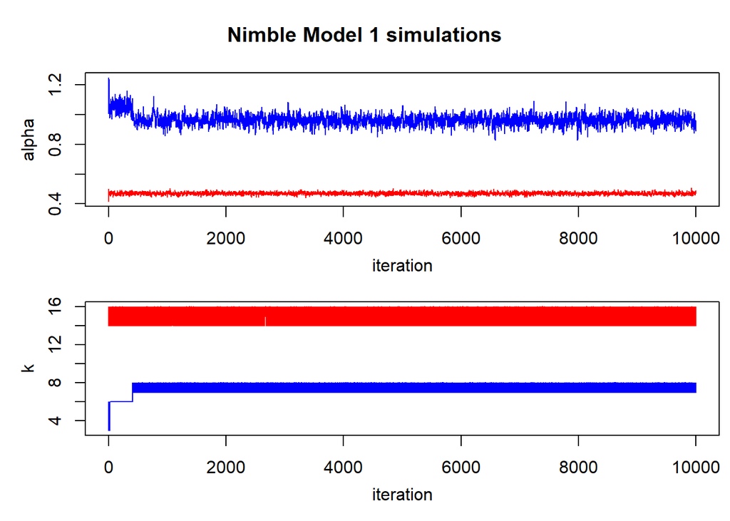

```r
sims = nimble.results1$samples

plot.results(chain1 = list("alpha" = sims$chain1[,"alpha"],
                           "k" = sims$chain1[,"k"]),
             chain2 = list("alpha" = sims$chain2[,"alpha"],
                           "k" = sims$chain2[,"k"]),
             monitors = c("alpha", "k"),
             main = "Nimble Model 1 simulations")
```

## STAN

```r
library("rstan")
options(mc.cores = parallel::detectCores())
rstan_options(auto_write = TRUE)

stan.results1 = stan('stagnant.stan',
                     data = c("N","x","Y"),
                     chains = 2,
                     iter = 2000)
cat(get_stancode(stan.results1))
```

```
## # Change point model with very poor parameterization from BUGS, vol 2
##
## // Bradley P. Carlin; Alan E. Gelfand; Adrian F. M. Smith.
## // Hierarchical Bayesian Analysis of Changepoint Problems
## // Applied Statistics, Vol. 41, No. 2. (1992), pp. 389-405.
## //
## // In these data, X represents the logarithm of the flow rate of
## // water down an inclined channel (grams per centimetre per second)
## // and Y represents the logarithm of the height of the stagnant
## // surface layer (centimetres) for different surfactants.
##
##
## data {
##   int<lower=0> N;
##   real x[N];
##   real Y[N];
## }
## parameters {
##   real<lower=0> sigma;
##   real<lower=0> alpha;
##   real beta[2];
##   simplex[N] theta;
## }
## model {
##   // local variables
##   real log_probs[N];
##   real mu[N];
##
##   // priors
##   theta ~ dirichlet(rep_vector(0.01,N));
##   alpha  ~ normal(0,5);
##   beta ~ normal(0,5);
##   sigma ~ cauchy(0,5);
##
##   // mixture likelihood
##   for (k in 1:N) {
##     for (n in 1:N)
##       mu[n] <- alpha + if_else(n <= k, beta[1], beta[2]) * (x[n] - x[k]);
##     log_probs[k] <- log(theta[k]) + normal_log(Y, mu, sigma);
##   }
##   increment_log_prob(log_sum_exp(log_probs));
## }
```

```r
print(stan.results1)
```

```
## Inference for Stan model: stagnant.
## 2 chains, each with iter=2000; warmup=1000; thin=1;
## post-warmup draws per chain=1000, total post-warmup draws=2000.
##
##            mean se_mean   sd  2.5%   25%   50%   75% 97.5% n_eff  Rhat
## sigma      0.08    0.01 0.01  0.06  0.07  0.07  0.08  0.11     5  1.15
## alpha      0.53    0.42 0.42  0.07  0.11  0.52  0.95  1.01     1 18.60
## beta[1]   -0.37    0.19 0.20 -0.60 -0.56 -0.48 -0.17 -0.03     1  3.41
## beta[2]   -1.11    0.30 0.30 -1.57 -1.40 -1.02 -0.81 -0.76     1  4.92
## theta[1]   0.01    0.00 0.06  0.00  0.00  0.00  0.00  0.07  1658  1.00
## theta[2]   0.01    0.00 0.06  0.00  0.00  0.00  0.00  0.02  1954  1.00
## theta[3]   0.01    0.00 0.06  0.00  0.00  0.00  0.00  0.04  2062  1.00
## theta[4]   0.01    0.00 0.07  0.00  0.00  0.00  0.00  0.12  2050  1.00
## theta[5]   0.01    0.00 0.06  0.00  0.00  0.00  0.00  0.05  2040  1.00
## theta[6]   0.01    0.00 0.06  0.00  0.00  0.00  0.00  0.04  1715  1.00
## theta[7]   0.05    0.04 0.22  0.00  0.00  0.00  0.00  0.99    32  1.12
## theta[8]   0.35    0.37 0.43  0.00  0.00  0.00  0.89  1.00     1  1.91
## theta[9]   0.01    0.00 0.06  0.00  0.00  0.00  0.00  0.06  1951  1.00
## theta[10]  0.01    0.00 0.05  0.00  0.00  0.00  0.00  0.04  1170  1.00
## theta[11]  0.01    0.00 0.05  0.00  0.00  0.00  0.00  0.02  1911  1.00
## theta[12]  0.01    0.00 0.06  0.00  0.00  0.00  0.00  0.08  1305  1.00
## theta[13]  0.01    0.00 0.06  0.00  0.00  0.00  0.00  0.05  1721  1.00
## theta[14]  0.01    0.00 0.06  0.00  0.00  0.00  0.00  0.04  1695  1.00
## theta[15]  0.01    0.00 0.06  0.00  0.00  0.00  0.00  0.05   791  1.00
## theta[16]  0.01    0.00 0.06  0.00  0.00  0.00  0.00  0.03  1373  1.00
## theta[17]  0.01    0.00 0.06  0.00  0.00  0.00  0.00  0.04  1933  1.00
## theta[18]  0.01    0.00 0.07  0.00  0.00  0.00  0.00  0.07  1635  1.00
## theta[19]  0.01    0.00 0.04  0.00  0.00  0.00  0.00  0.03  1339  1.00
## theta[20]  0.01    0.00 0.06  0.00  0.00  0.00  0.00  0.05   928  1.00
## theta[21]  0.01    0.00 0.06  0.00  0.00  0.00  0.00  0.04  2011  1.00
## theta[22]  0.39    0.40 0.43  0.00  0.00  0.05  0.91  1.00     1  2.35
## theta[23]  0.01    0.00 0.06  0.00  0.00  0.00  0.00  0.09  1254  1.00
## theta[24]  0.01    0.00 0.05  0.00  0.00  0.00  0.00  0.03  1064  1.00
## theta[25]  0.01    0.00 0.05  0.00  0.00  0.00  0.00  0.03  1128  1.00
## theta[26]  0.01    0.00 0.06  0.00  0.00  0.00  0.00  0.04  1378  1.00
## theta[27]  0.00    0.00 0.04  0.00  0.00  0.00  0.00  0.01  1922  1.00
## theta[28]  0.01    0.00 0.06  0.00  0.00  0.00  0.00  0.02   907  1.00
## theta[29]  0.02    0.00 0.10  0.00  0.00  0.00  0.00  0.29  1361  1.00
## lp__       3.41    0.80 5.80 -8.78 -0.59  3.87  7.58 13.26    52  1.04
##
## Samples were drawn using NUTS(diag_e) at Thu Sep 10 10:22:36 2020.
## For each parameter, n_eff is a crude measure of effective sample size,
## and Rhat is the potential scale reduction factor on split chains (at
## convergence, Rhat=1).
```

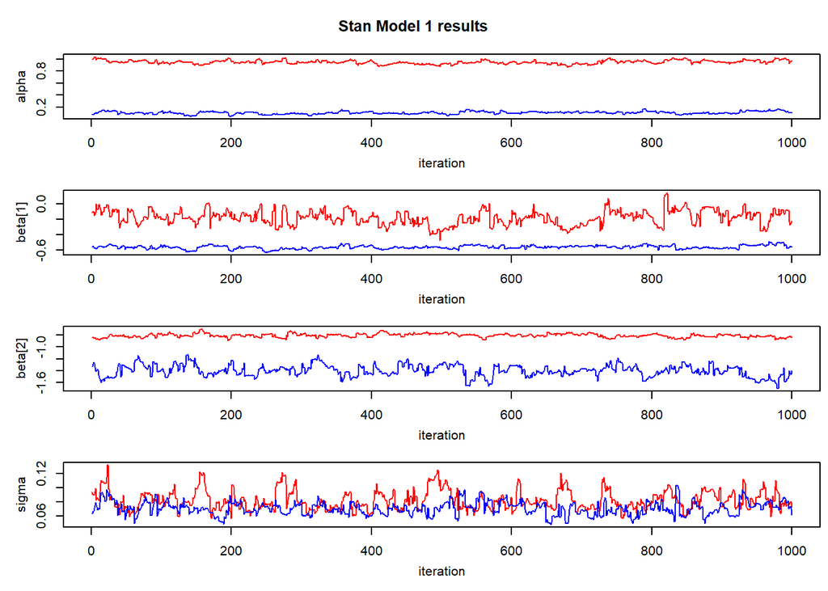

```r
sims = as.array(stan.results1)

plot.results(list("alpha" = sims[,1,"alpha"],
                  "beta[1]" = sims[,1,"beta[1]"],
                  "beta[2]" = sims[,1,"beta[2]"],
                  "sigma" = sims[,1,"sigma"]),
             list("alpha" = sims[,2,"alpha"],
                  "beta[1]" = sims[,2,"beta[1]"],
                  "beta[2]" = sims[,2,"beta[2]"],
                  "sigma" = sims[,2,"sigma"]),
             monitors = c("alpha", "beta[1]", "beta[2]", "sigma"),
             main = "Stan Model 1 results")
```

# Second model

```r
cat("model {
  for(i in 1 : N) {
    Y[i] ~ dnorm(mu[i], tau)
    mu[i] <- alpha + beta[J[i]] * (x[i] - x.change)
    J[i] <- 1 + step(x[i] - x.change)
  }
  tau ~ dgamma(0.001, 0.001)
  alpha ~ dnorm(0.0,1.0E-6)
  for(j in 1 : 2) {
    beta[j] ~ dnorm(0.0,1.0E-6)
  }
  sigma <- 1 / sqrt(tau)
  x.change ~ dunif(-1.3,1.1)
}")
```

```
## model {
##   for(i in 1 : N) {
##     Y[i] ~ dnorm(mu[i], tau)
##     mu[i] <- alpha + beta[J[i]] * (x[i] - x.change)
##     J[i] <- 1 + step(x[i] - x.change)
##   }
##   tau ~ dgamma(0.001, 0.001)
##   alpha ~ dnorm(0.0,1.0E-6)
##   for(j in 1 : 2) {
##     beta[j] ~ dnorm(0.0,1.0E-6)
##   }
##   sigma <- 1 / sqrt(tau)
##   x.change ~ dunif(-1.3,1.1)
## }
```

## OpenBUGS

Now we use R2OpenBUGS to sample from the posterior.

```r
library(R2OpenBUGS)
data = list("N", "Y", "x")

par2 = c("alpha", "beta", "sigma", "x.change")

openbugs.results2 = bugs(data = data,
                         inits = inits2,
                         parameters.to.save = par2,
                         model = "stagnant_model2.txt",
                         n.chains = 2,
                         n.iter = 10000,
                         n.thin = 1,
                         n.burnin = 0,
                         debug = FALSE,
                         DIC = TRUE)

# Print summary
print(openbugs.results2)
```

```
## Inference for Bugs model at "stagnant_model2.txt",
##  2 chains, each with 10000 iterations (first 0 discarded)
##  n.sims = 20000 iterations saved
##            mean   sd   2.5%    25%    50%    75% 97.5% Rhat n.eff
## alpha       0.5  0.1    0.3    0.5    0.5    0.5   0.6    1   350
## beta[1]    -0.4  0.0   -0.5   -0.4   -0.4   -0.4  -0.4    1   110
## beta[2]    -1.0  0.0   -1.1   -1.0   -1.0   -1.0  -1.0    1  2000
## sigma       0.0  0.0    0.0    0.0    0.0    0.0   0.0    1   680
## x.change    0.0  0.1    0.0    0.0    0.0    0.1   0.3    1   340
## deviance -140.4 16.0 -149.4 -146.7 -144.3 -140.6 -93.4    1   540
##
## For each parameter, n.eff is a crude measure of effective sample size,
## and Rhat is the potential scale reduction factor (at convergence, Rhat=1).
##
## DIC info (using the rule, pD = Dbar-Dhat)
## pD = 7.7 and DIC = -132.7
## DIC is an estimate of expected predictive error (lower deviance is better).
```

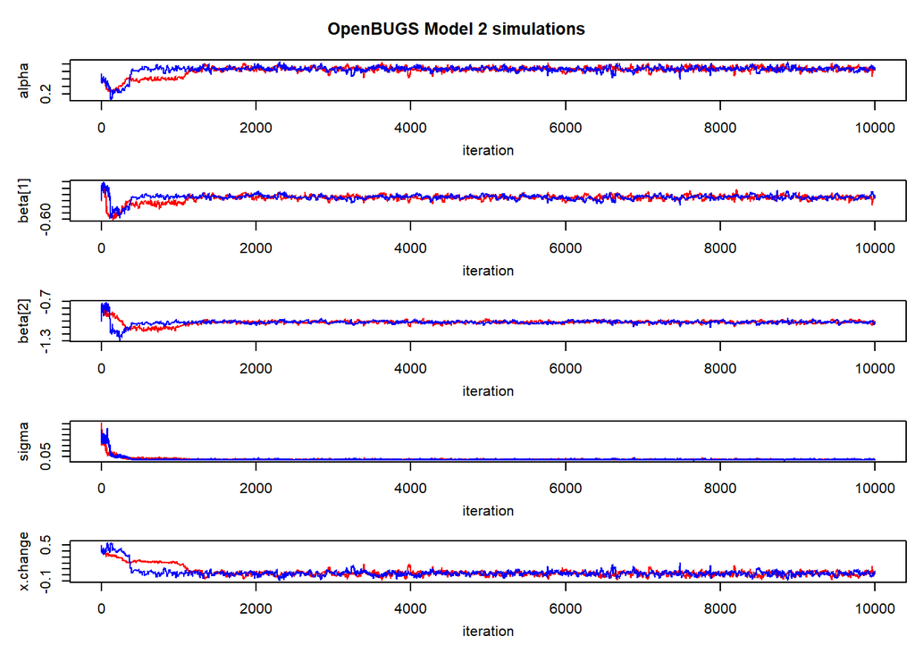

```r
sims = openbugs.results2$sims.array

plot.results(list("alpha" = sims[,1,"alpha"],
                  "beta[1]" = sims[,1,"beta[1]"],
                  "beta[2]" = sims[,1,"beta[2]"],
                  "sigma" = sims[,1,"sigma"],
                  "x.change" = sims[,1,"x.change"]),
             list("alpha" = sims[,2,"alpha"],
                  "beta[1]" = sims[,2,"beta[1]"],
                  "beta[2]" = sims[,2,"beta[2]"],
                  "sigma" = sims[,2,"sigma"],
                  "x.change" = sims[,2,"x.change"]),
             monitors = c("alpha", "beta[1]", "beta[2]", "sigma", "x.change"),
             main = "OpenBUGS Model 2 simulations")
```

Plot alpha against x.change. We can still see that these to variables are correlated.

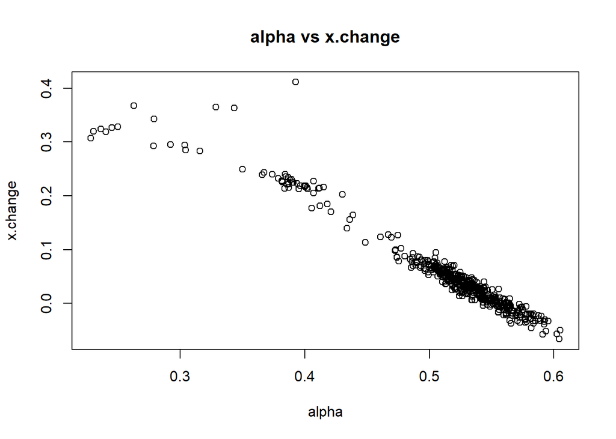

```r
index = sample(1:10000, 500)
plot(sims[index, 1, "alpha"], sims[index, 1, "x.change"], xlab = "alpha", ylab = "x.change",
     main = "alpha vs x.change")
```

## JAGS

Now we use JAGS to sample from the posterior.

```r
library(R2jags)
data = list("N", "Y", "x")

par2 = c("alpha", "beta", "sigma", "x.change")

jags.result2 = jags(data = data,
                    inits = inits2,
                    parameters.to.save = par2,
                    model = "stagnant_model2.txt",
                    n.chains = 2,
                    n.iter = 10000,
                    n.thin = 1,
                    n.burnin = 0,
                    DIC = TRUE)
# Print summary
print(jags.result2)
```

```
## Inference for Bugs model at "stagnant_model2.txt", fit using jags,
##  2 chains, each with 10000 iterations (first 0 discarded)
##  n.sims = 20000 iterations saved
##           mu.vect sd.vect     2.5%      25%      50%      75%    97.5%  Rhat
## alpha       0.536   0.025    0.488    0.520    0.535    0.553    0.586 1.001
## beta[1]    -0.419   0.015   -0.448   -0.429   -0.419   -0.409   -0.389 1.001
## beta[2]    -1.013   0.017   -1.048   -1.025   -1.013   -1.002   -0.980 1.002
## sigma       0.022   0.003    0.017    0.020    0.022    0.024    0.030 1.001
## x.change    0.027   0.032   -0.037    0.005    0.028    0.048    0.086 1.002
## deviance -143.967   4.032 -149.465 -146.928 -144.784 -141.838 -134.060 1.001
##          n.eff
## alpha     3600
## beta[1]  12000
## beta[2]   1500
## sigma    20000
## x.change  2300
## deviance 20000
##
## For each parameter, n.eff is a crude measure of effective sample size,
## and Rhat is the potential scale reduction factor (at convergence, Rhat=1).
##
## DIC info (using the rule, pD = var(deviance)/2)
## pD = 8.1 and DIC = -135.8
## DIC is an estimate of expected predictive error (lower deviance is better).
```

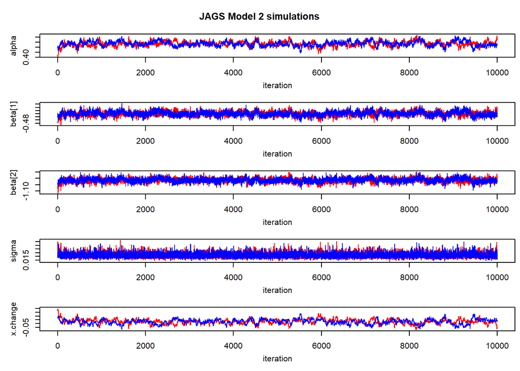

```r
sims = jags.result2$BUGSoutput$sims.array

plot.results(list("alpha" = sims[,1,"alpha"],
                  "beta[1]" = sims[,1,"beta[1]"],
                  "beta[2]" = sims[,1,"beta[2]"],
                  "sigma" = sims[,1,"sigma"],
                  "x.change" = sims[,1,"x.change"]),
             list("alpha" = sims[,2,"alpha"],
                  "beta[1]" = sims[,2,"beta[1]"],
                  "beta[2]" = sims[,2,"beta[2]"],
                  "sigma" = sims[,2,"sigma"],
                  "x.change" = sims[,2,"x.change"]),
             monitors = c("alpha", "beta[1]", "beta[2]", "sigma", "x.change"),
             main = "JAGS Model 2 simulations")
```

## Nimble

```r
library(nimble, warn.conflicts = FALSE)

dataNimble = list(x = x, Y = Y)
constants = list(N = N)
monitors.model2 = list("alpha", "beta", "sigma", "x.change")

# model configuration
code.model2 = nimbleCode({
   for(i in 1 : N) {
      Y[i] ~ dnorm(mu[i],  tau)
      mu[i] <- alpha + beta[J[i]] * (x[i] - x.change)
      J[i] <- 1 + step(x[i] - x.change)
   }
   # Y ~ dnorm(mu,  tau)
   # mu <- alpha + beta[J] * (x - x.change)
   # J <- 1 + step(x - x.change)
   tau ~ dgamma(0.001, 0.001)
   alpha ~ dnorm(0.0,1.0E-6)

   for(j in 1:2){
      beta[j] ~ dnorm(0.0,1.0E-6)
   }
   sigma <-  1 / sqrt(tau)
   x.change ~ dunif(-1.3,1.1)
})

nimble.model2 = nimbleModel(code.model2,
                     constants = constants,
                     data = dataNimble,
                     inits = inits2$chain1)
```

```
## defining model...
```

```
## building model...
```

```
## setting data and initial values...
```

```
## running calculate on model (any error reports that follow may simply reflect missing values in model variables) ...
## checking model sizes and dimensions...
## model building finished.
```

```r
# MCMC configuration and building
mcmc.conf.model2 = configureMCMC(nimble.model2, monitors = monitors.model2)
```

```
## ===== Monitors =====
## thin = 1: alpha, beta, sigma, x.change
## ===== Samplers =====
## RW sampler (1)
##   - x.change
## conjugate sampler (4)
##   - tau
##   - alpha
##   - beta[]  (2 elements)
```

```r
mcmc.model2 = buildMCMC(mcmc.conf.model2, monitors = monitors.model2)

# compile to C++, and run
compiled.model2 = compileNimble(nimble.model2)
```

```
## compiling... this may take a minute. Use 'showCompilerOutput = TRUE' to see C++ compilation details.
## compilation finished.
```

```r
compiled.mcmc.model2 = compileNimble(mcmc.model2, project = nimble.model2)
```

```
## compiling... this may take a minute. Use 'showCompilerOutput = TRUE' to see C++ compilation details.
## compilation finished.
```

```r
# run multiple MCMC chains
nimble.results2 = runMCMC(compiled.mcmc.model2,
                          nburnin = 0,
                          inits = inits2,
                          niter = 10000,
                          nchains = 2,
                          summary = TRUE)
```

```
## running chain 1...
```

```
## |-------------|-------------|-------------|-------------|
## |-------------------------------------------------------|
```

```
## running chain 2...
```

```
## |-------------|-------------|-------------|-------------|
## |-------------------------------------------------------|
```

```r
# Print summary
print(nimble.results2$summary)
```

```
## $chain1
##                 Mean      Median     St.Dev.   95%CI_low  95%CI_upp
## alpha     0.50929314  0.52606117 0.073393842  0.20851350  0.5774308
## beta[1]  -0.42900875 -0.42429952 0.027145096 -0.51903869 -0.3933660
## beta[2]  -1.03159435 -1.01869514 0.062055899 -1.28171779 -0.9828896
## sigma     0.02379518  0.02206906 0.008371355  0.01677017  0.0531271
## x.change  0.06279169  0.03964777 0.098897452 -0.02506854  0.4826880
##
## $chain2
##                 Mean      Median     St.Dev.   95%CI_low  95%CI_upp
## alpha     0.51360227  0.52681251 0.074062875  0.20604481  0.5916843
## beta[1]  -0.42721342 -0.42340381 0.027259795 -0.51853682 -0.3884879
## beta[2]  -1.02981862 -1.01737323 0.063671860 -1.28143465 -0.9796939
## sigma     0.02384032  0.02202105 0.008200188  0.01686633  0.0528959
## x.change  0.05708419  0.03993068 0.100243973 -0.04414683  0.4897687
##
## $all.chains
##                 Mean      Median     St.Dev.   95%CI_low   95%CI_upp
## alpha     0.51144770  0.52641982 0.073758751  0.20719032  0.58601424
## beta[1]  -0.42811108 -0.42386067 0.027216634 -0.51883171 -0.39099922
## beta[2]  -1.03070649 -1.01808022 0.062873769 -1.28146786 -0.98127004
## sigma     0.02381775  0.02203833 0.008286037  0.01681115  0.05296463
## x.change  0.05993794  0.03973166 0.099611388 -0.03777304  0.48470354
```

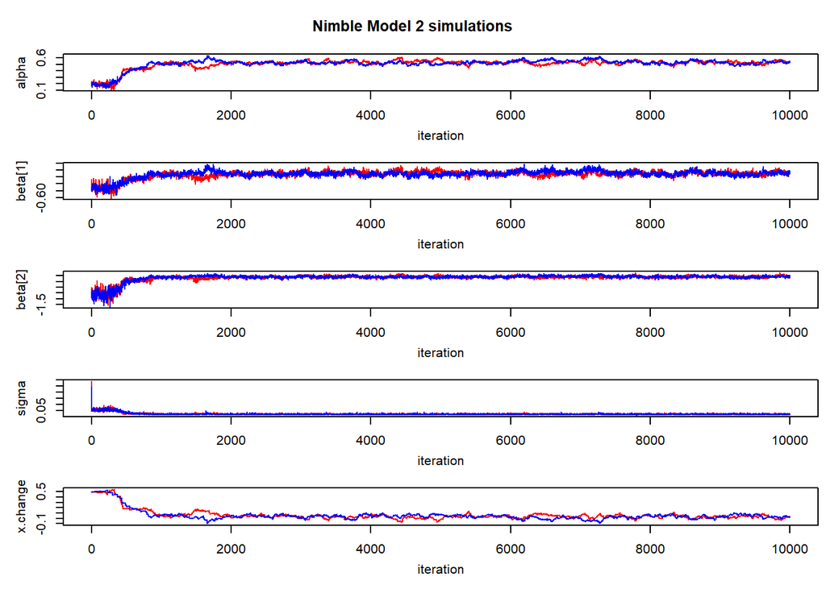

```r
sims = nimble.results2$samples

plot.results(chain1 = list("alpha" = sims$chain1[,"alpha"],
                           "beta[1]" = sims$chain1[,"beta[1]"],
                           "beta[2]" = sims$chain1[,"beta[2]"],
                           "sigma" = sims$chain1[,"sigma"],
                           "x.change" = sims$chain1[,"x.change"]),
             chain2 = list("alpha" = sims$chain2[,"alpha"],
                           "beta[1]" = sims$chain2[,"beta[1]"],
                           "beta[2]" = sims$chain2[,"beta[2]"],
                           "sigma" = sims$chain2[,"sigma"],
                           "x.change" = sims$chain2[,"x.change"]),
             monitors = c("alpha", "beta[1]", "beta[2]", "sigma", "x.change"),
             main = "Nimble Model 2 simulations")
```

## STAN

```r
library("rstan")
options(mc.cores = parallel::detectCores())
rstan_options(auto_write = TRUE)

stan.results2 = stan('stagnant2.stan',
                     data = c("N","x","Y"),
                     chains = 2,
                     iter = 2000)
```

```
## hash mismatch so recompiling; make sure Stan code ends with a blank line
```

```r
cat(get_stancode(stan.results2))
```

```
## data {
##   int<lower=0> N;
##   real x[N];
##   real Y[N];
## }
## parameters {
##   real<lower=0> sigma;
##   real<lower=0> alpha;
##   real beta[2];
##   real<lower=min(x),upper=max(x)> x_change;
## }
## model {
##   real mu[N];
##
##   alpha  ~ normal(0,5);
##   beta ~ normal(0,5);
##   sigma ~ cauchy(0,5);
##
##   for (n in 1:N)
##     mu[n] <- alpha
##       + if_else(x[n] < x_change, beta[1], beta[2]) * (x[n] - x_change);
##
##   Y ~ normal(mu,sigma);
## }
```

```r
print(stan.results2)
```

```
## Inference for Stan model: stagnant2.
## 2 chains, each with iter=2000; warmup=1000; thin=1;
## post-warmup draws per chain=1000, total post-warmup draws=2000.
##
##           mean se_mean   sd  2.5%   25%   50%   75% 97.5% n_eff Rhat
## sigma     0.02    0.00 0.00  0.02  0.02  0.02  0.02  0.03   938 1.00
## alpha     0.54    0.00 0.02  0.49  0.52  0.53  0.55  0.58   316 1.00
## beta[1]  -0.42    0.00 0.01 -0.44 -0.43 -0.42 -0.41 -0.39   421 1.00
## beta[2]  -1.01    0.00 0.02 -1.04 -1.02 -1.01 -1.00 -0.98   680 1.00
## x_change  0.03    0.00 0.03 -0.03  0.01  0.03  0.05  0.08   314 1.00
## lp__     94.06    0.08 1.77 89.37 93.20 94.43 95.35 96.42   554 1.01
##
## Samples were drawn using NUTS(diag_e) at Thu Sep 10 10:23:54 2020.
## For each parameter, n_eff is a crude measure of effective sample size,
## and Rhat is the potential scale reduction factor on split chains (at
## convergence, Rhat=1).
```

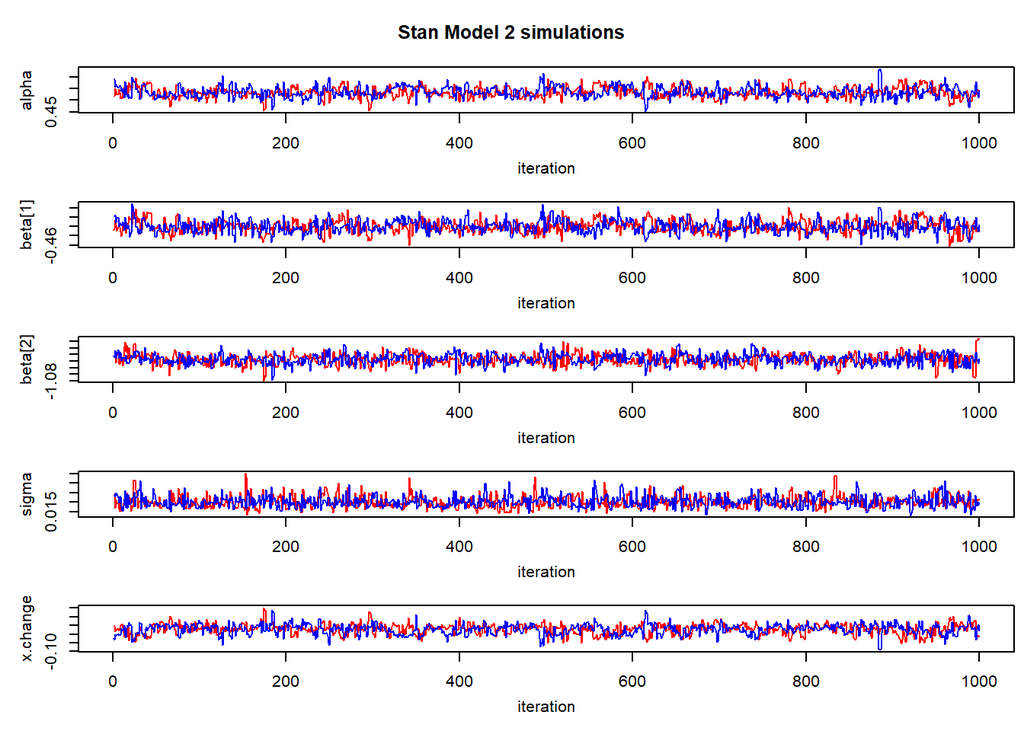

```r
sims = as.array(stan.results2)

plot.results(list("alpha" = sims[,1,"alpha"],
                  "beta[1]" = sims[,1,"beta[1]"],
                  "beta[2]" = sims[,1,"beta[2]"],
                  "sigma" = sims[,1,"sigma"],
                  "x.change" = sims[,1,"x_change"]),
             list("alpha" = sims[,2,"alpha"],
                  "beta[1]" = sims[,2,"beta[1]"],
                  "beta[2]" = sims[,2,"beta[2]"],
                  "sigma" = sims[,2,"sigma"],
                  "x.change" = sims[,2,"x_change"]),
             monitors = c("alpha", "beta[1]", "beta[2]", "sigma", "x.change"),
             main = "Stan Model 2 simulations")
```